# CLT Convergence: Cauchy

```r
source("../R/clt_functions.R")

student_id <- 8515     # last 4 digits of my student ID
B          <- 10000    # number of simulated samples (NOT the sample size)
pop        <- "cauchy"
```

## 1. What does the population look like?

X ~ Cauchy(location = 0, scale = 1), generated with `rcauchy()`. Extremely heavy tails.

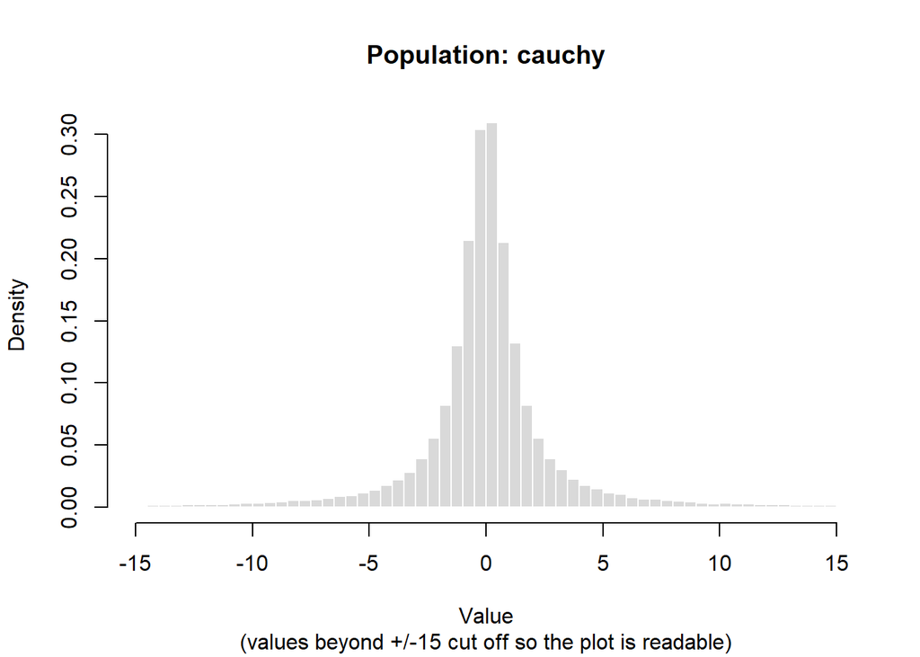

```r
plot_population(pop, seed = student_id)
```

The Cauchy has **no** mean and **no** variance (the integrals don’t converge), so σ/√n doesn’t exist. The theory columns in the table are NA on purpose.

**Pass 1 (coarse):** a wide grid to find roughly where the change happens.

```r
ns_coarse <- c(2, 5, 10, 20, 30, 50, 100, 200, 500)
coarse    <- run_study(pop, ns_coarse, B = B, seed = student_id)
knitr::kable(coarse$table, digits = 4)
```

| n | sim_mean | theo_mean | sim_se | theo_se | se_ratio | skewness | ex_kurt | qq_cor | shapiro_p |
| --- | --- | --- | --- | --- | --- | --- | --- | --- | --- |
| 2 | -1.6750 | NA | 139.0515 | NA | NA | -59.1557 | 4000.4451 | 0.1437 | 0 |
| 5 | 0.4289 | NA | 80.3858 | NA | NA | 7.9316 | 2626.1563 | 0.1893 | 0 |
| 10 | 0.7130 | NA | 55.0599 | NA | NA | 20.6131 | 1613.4187 | 0.2429 | 0 |
| 20 | 0.5150 | NA | 41.3022 | NA | NA | 16.9009 | 911.1284 | 0.3144 | 0 |
| 30 | 1.6528 | NA | 119.9903 | NA | NA | 86.9989 | 8244.3185 | 0.1366 | 0 |
| 50 | 0.7769 | NA | 123.2742 | NA | NA | -11.4092 | 3550.7559 | 0.1541 | 0 |
| 100 | 0.7204 | NA | 69.4428 | NA | NA | -1.5729 | 2467.5549 | 0.2076 | 0 |
| 200 | -0.4773 | NA | 95.5008 | NA | NA | -49.7870 | 3755.8883 | 0.1739 | 0 |
| 500 | -1.1534 | NA | 142.3050 | NA | NA | -62.3122 | 5619.6716 | 0.1494 | 0 |

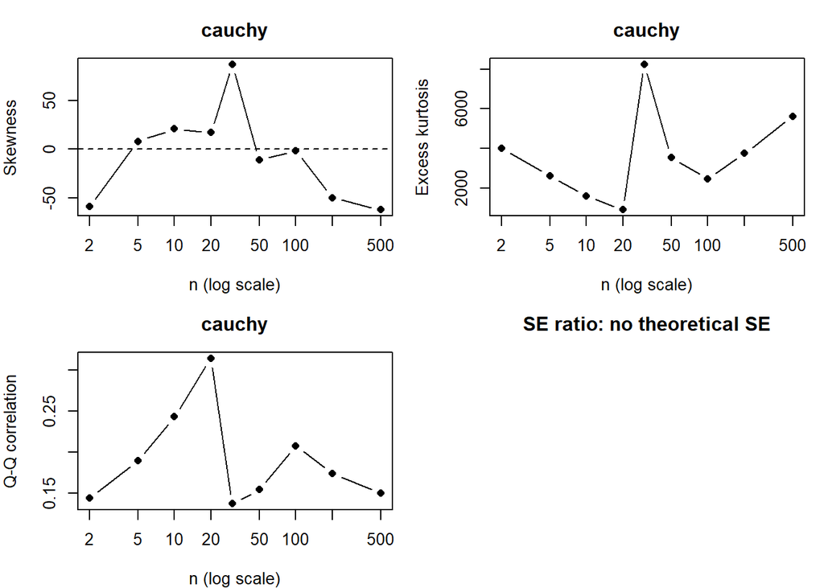

```r
plot_convergence(coarse$table, pop)
```

**Pass 2 (extended):** much larger values, since nothing passed in pass 1.

```r
ns_fine <- c(1000, 2000, 5000)   # nothing passed in pass 1, so test much larger n
fine    <- run_study(pop, ns_fine, B = B, seed = student_id)
knitr::kable(fine$table, digits = 4)
```

| n | sim_mean | theo_mean | sim_se | theo_se | se_ratio | skewness | ex_kurt | qq_cor | shapiro_p |
| --- | --- | --- | --- | --- | --- | --- | --- | --- | --- |
| 1000 | -0.6638 | NA | 90.2615 | NA | NA | -20.1558 | 2766.078 | 0.1976 | 0 |
| 2000 | -1.4360 | NA | 95.8523 | NA | NA | -32.5785 | 1905.948 | 0.1973 | 0 |
| 5000 | 0.5332 | NA | 122.5874 | NA | NA | 79.0928 | 7465.327 | 0.1429 | 0 |

Nothing in pass 1 came close to passing: skewness, kurtosis and Q-Q correlation were far from normal at every n up to 500, with no downward trend. Instead of refining, I extended the search to much larger samples (n = 1,000, 2,000 and 5,000) to check whether normality appears at very large n. It did not.

**Does averaging shrink the spread?** For a distribution with finite variance, the middle 50% of the sample means (the IQR) should shrink like 1/√n. Here is what happens for the Cauchy:

```r
iqr_tbl <- data.frame(n = c(1, 10, 100, 1000))
iqr_tbl$IQR_of_means <- sapply(iqr_tbl$n, function(n)
  IQR(simulate_means(populations[[pop]], n, B, student_id)))
knitr::kable(iqr_tbl, digits = 3)
```

| n | IQR_of_means |
| --- | --- |
| 1 | 2.030 |
| 10 | 1.994 |
| 100 | 1.985 |
| 1000 | 2.017 |

## 5. Simulated vs. theoretical mean and standard error

The table columns `sim_mean` / `theo_mean` and `sim_se` / `theo_se` compare the simulation with the CLT’s predictions. `se_ratio` = simulated SE ÷ σ/√n, so 1 means a perfect match.

There is no theoretical mean or standard error to compare against, because the Cauchy has no mean and no variance; that is why the theory columns are NA. The simulated means stayed scattered between about −1.7 and +1.7 with no sign of settling, and the simulated SD of the means stayed between 41 and 142 instead of shrinking like 1/√n. Both results show that the usual σ/√n formula cannot be used here.

## 6. My “normal enough” standard and the chosen n

```r
# My "normal enough" standard, used identically in every file
criteria <- list(
  max_abs_skew = 0.25,    # mild skew; tighter is within Monte Carlo noise
  max_abs_kurt = 0.3,     # tails close to normal
  min_qq_cor   = 0.998    # Q-Q plot essentially straight
)

all_results <- rbind(coarse$table, fine$table)
all_results <- all_results[!duplicated(all_results$n), ]
all_results <- all_results[order(all_results$n), ]
all_results$passes <- passes_standard(all_results, criteria)
knitr::kable(all_results, digits = 4)
```

| n | sim_mean | theo_mean | sim_se | theo_se | se_ratio | skewness | ex_kurt | qq_cor | shapiro_p | passes |
| --- | --- | --- | --- | --- | --- | --- | --- | --- | --- | --- |
| 2 | -1.6750 | NA | 139.0515 | NA | NA | -59.1557 | 4000.4451 | 0.1437 | 0 | FALSE |
| 5 | 0.4289 | NA | 80.3858 | NA | NA | 7.9316 | 2626.1563 | 0.1893 | 0 | FALSE |
| 10 | 0.7130 | NA | 55.0599 | NA | NA | 20.6131 | 1613.4187 | 0.2429 | 0 | FALSE |
| 20 | 0.5150 | NA | 41.3022 | NA | NA | 16.9009 | 911.1284 | 0.3144 | 0 | FALSE |
| 30 | 1.6528 | NA | 119.9903 | NA | NA | 86.9989 | 8244.3185 | 0.1366 | 0 | FALSE |
| 50 | 0.7769 | NA | 123.2742 | NA | NA | -11.4092 | 3550.7559 | 0.1541 | 0 | FALSE |
| 100 | 0.7204 | NA | 69.4428 | NA | NA | -1.5729 | 2467.5549 | 0.2076 | 0 | FALSE |
| 200 | -0.4773 | NA | 95.5008 | NA | NA | -49.7870 | 3755.8883 | 0.1739 | 0 | FALSE |
| 500 | -1.1534 | NA | 142.3050 | NA | NA | -62.3122 | 5619.6716 | 0.1494 | 0 | FALSE |
| 1000 | -0.6638 | NA | 90.2615 | NA | NA | -20.1558 | 2766.0781 | 0.1976 | 0 | FALSE |
| 2000 | -1.4360 | NA | 95.8523 | NA | NA | -32.5785 | 1905.9485 | 0.1973 | 0 | FALSE |
| 5000 | 0.5332 | NA | 122.5874 | NA | NA | 79.0928 | 7465.3266 | 0.1429 | 0 | FALSE |

```r
smallest_normal_n(all_results, criteria)
```

```
[1] NA
```

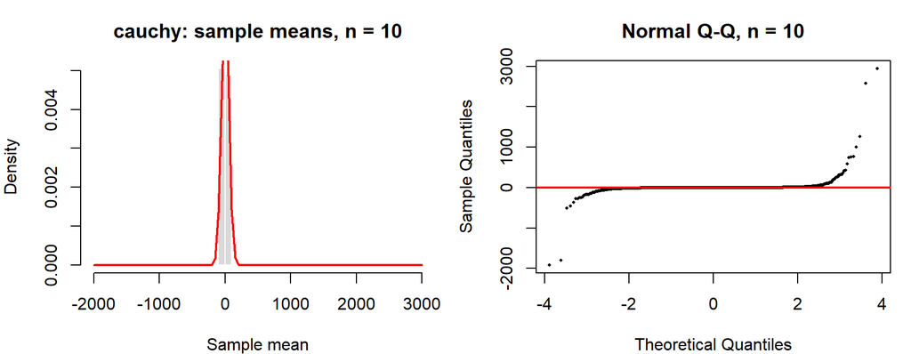

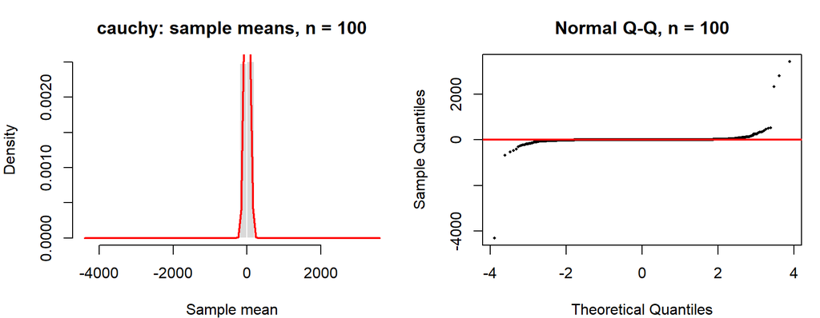

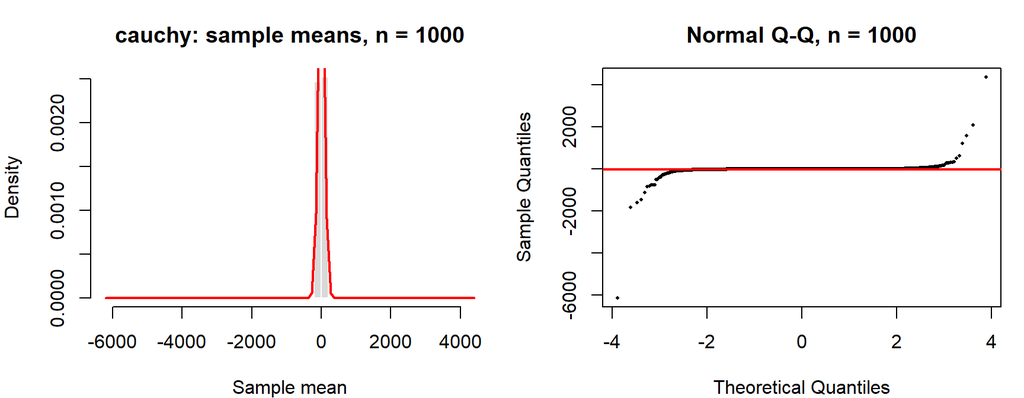

```r
# Show small, medium, and very large n
for (n in c(10, 100, 1000)) {
  plot_diagnostics(simulate_means(populations[[pop]], n, B, student_id), n, pop)
}
```

$$\boxed{\text{No } n \text{ works: the CLT does not apply}}$$

I used the same standard as every other population: |skewness| ≤ 0.25, |excess kurtosis| ≤ 0.3, and Q-Q correlation ≥ 0.998. No sample size passed, even after extending the search to n = 5,000. Skewness swung randomly between −62 and +87, excess kurtosis stayed between about 900 and 8,200, and the Q-Q correlation never rose above 0.32. None of the measures showed any trend toward normality as n increased. The histograms show a single narrow spike with a few extreme values far away, and the Q-Q plots are flat in the middle with points shooting off at both ends. This is the pattern of extremely heavy tails, and it looks the same at n = 10, 100 and 1,000. The IQR table confirms it: the spread of the sample means does not shrink with n. The CLT requires a finite variance, and the Cauchy has no finite mean or variance, so the CLT does not apply. My conclusion is that there is no n at which the sample mean becomes approximately normal.

## 7. Limitations and surprises

The most surprising result was that averaging did not reduce the spread at all. The IQR of the sample means was 2.03 at n = 1 and still 2.02 at n = 1,000. For every other population, the spread shrank like 1/√n. The explanation is a known property of the Cauchy: the mean of n independent Cauchy(0, 1) values has exactly the same Cauchy(0, 1) distribution as a single value. Averaging 1,000 observations gives no more information about the center than one observation does. I was also surprised that the simulated SD of the means got neither smaller nor stable as n grew (139 at n = 2, 142 at n = 500, 123 at n = 5,000). Each run is dominated by a few enormous values, because the Cauchy’s tails are so heavy that its variance is infinite.